# Summary of RNA-seq data cleaning

### Assess total aligned counts

Assess aligned counts per library. Higher counts indicate high coverage and are preferred. The minimum total sequences cutoff set above is indicated by a horizontal line.

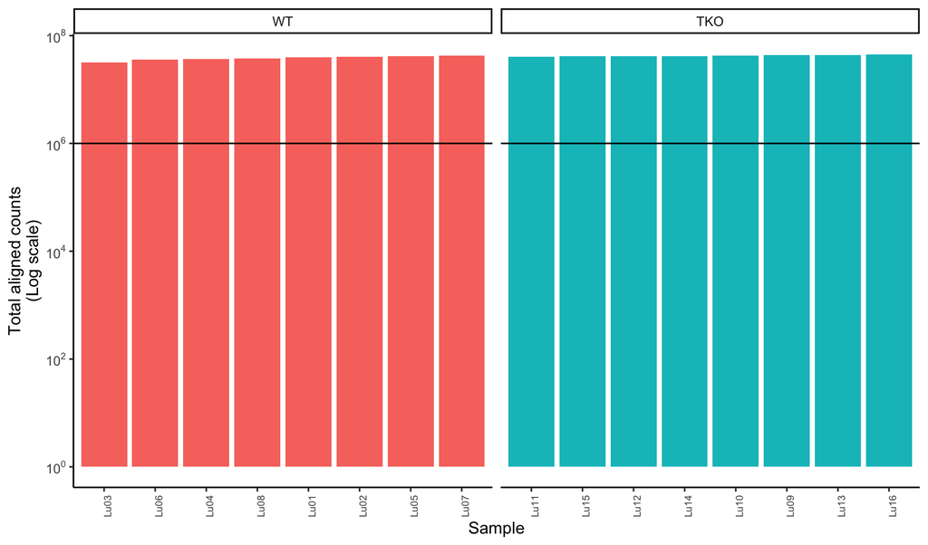

### Filter by library coverage

No samples need to be removed.

## 9. Filter PCA outliers

### PCA of variables of interest

If one or more variables of interest represents significant variation in the data, consider further filtering and normalizing separately. This is most common when multiple sample or cell types exist in the data set.

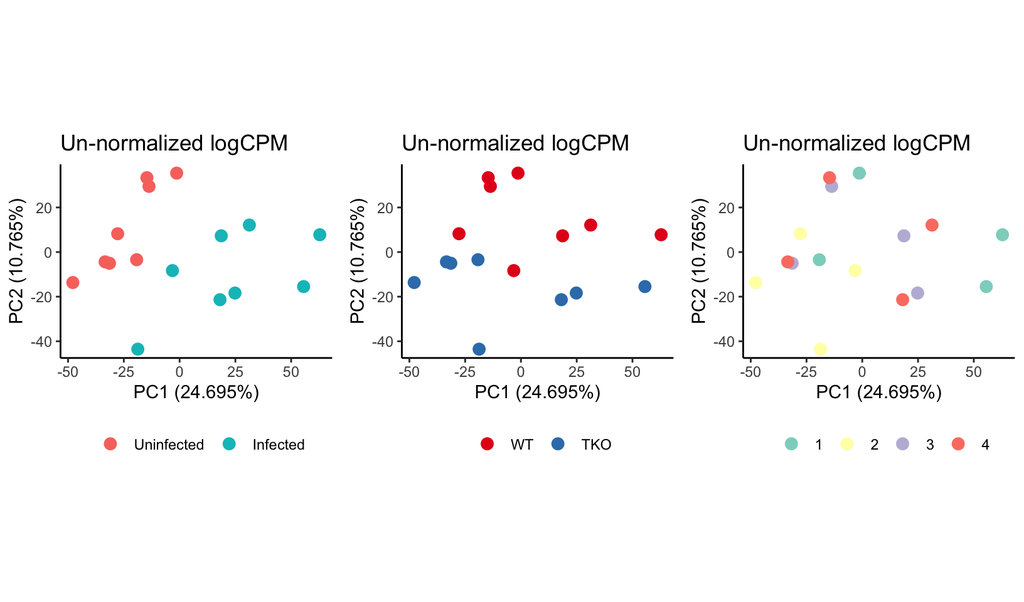

### PCA of potential outliers

Visualize PCA outliers defined as any library with PC1 and/or PC2 values greater than 3 standard deviations away from the PC mean.

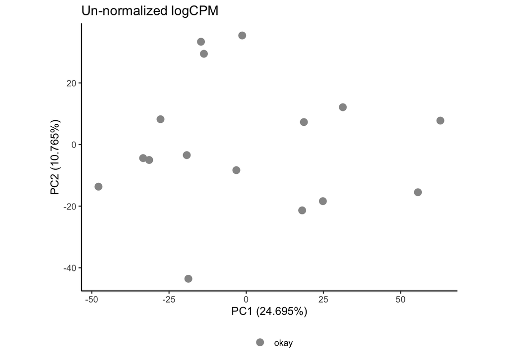

### Filter PCA outliers

No PCA outliers exist in the data.

## 10. Filter rare genes

### Create DGEList object

For use in gene filtering with edgeR

```r
dat.pc <- DGEList(
  #count table. move gene names to column names
  counts=as.matrix(column_to_rownames(counts.pc,
                                      "geneName")),
  #metadata
  samples=meta,
  #keep genes in count table
  genes=key.pc)
```

### Filter rare genes

The raw gene sets contain highly variable, low abundance/rare genes.

Filters genes to those with `min.CPM` (counts per million) in at least `min.pct` (percent of samples) or `min.sample` (number of samples).

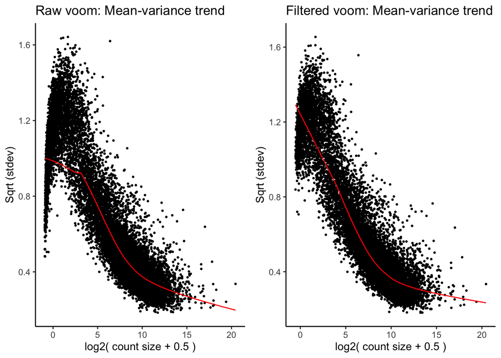

```r
#Get Kim's function from GitHub
source("https://raw.githubusercontent.com/kdillmcfarland/R_bioinformatic_scripts/master/RNAseq_rare_gene_filter.R")

#Filter
rare.gene.filter(dat = dat.pc,
                 min.sample = 3,
                 min.CPM = 0.1,
                 name = "dat.pc.abund")
```

This removes 7635 (~ 35%) genes.

## 11. Normalize counts

### Normalize for RNA composition

Calculate factors to scale library sizes.

```r
dat.pc.abund.norm <- calcNormFactors(dat.pc.abund)
```

### Normalize with voom

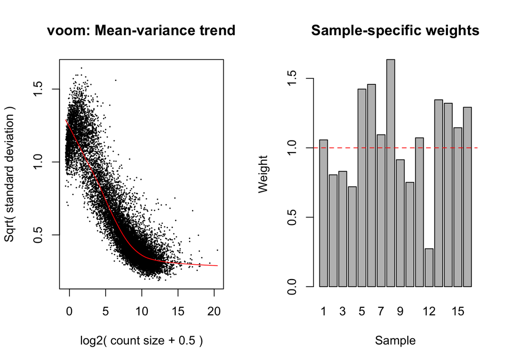

```r
dat.pc.abund.norm.voom <- voomWithQualityWeights(
                          dat.pc.abund.norm,
                          design = model.matrix(VOI.model,
                                 data=  dat.pc.abund.norm$samples),
                          plot=TRUE)
```

### Re-check for PCA outliers

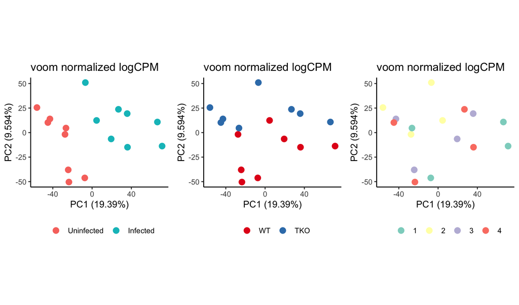

## Summary 2

No samples were removed due to low quality or coverage. In total, 7635 (~ 35%) genes were removed due to low abundance.

# Save data

Write as RData

```r
#Rename to short form
dat.voom <- dat.pc.abund.norm.voom

save(dat.voom, file="data_clean/Shah.clean.RData")
```

Write counts as table.

```r
#Counts table
as.data.frame(dat.pc.abund.norm.voom$E) %>%
  rownames_to_column("geneName") %>%
write_csv("results/gene_level/Shah_gene_voom_counts.csv")
```